# Replicate baseline model - CNN-based deep canonical correlation analysis autoencoder (CNN-DCCAE)

```python
# import libraries
import torch
from torch import nn
import torch.nn.functional as F
import torch.optim as optim
from torch.utils.data import DataLoader, Dataset, WeightedRandomSampler
from sklearn import metrics
import matplotlib.pyplot as plt
import numpy as np
from sklearn.model_selection import train_test_split
from braindecode.datautil.serialization import load_concat_dataset
from braindecode.datasets import BaseConcatDataset, BaseDataset
from braindecode.preprocessing import create_fixed_length_windows
from collections import Counter
from tqdm import tqdm
import plotly.express as px
import pandas as pd
```

```python
# Load the rescaled data
OUT_PATH = r'D:\Ana_Maria\cleaned_TUH_scaled'
tuh_preproc = load_concat_dataset(OUT_PATH, preload=False)
```

```python
# Count how many segment we have in each class
t = []
for ds in tuh_preproc.datasets:
    ds.target_name = int(ds.description['target'])
    ds.target_name = 'target'
    t.append(int(ds.description['target']))

Counter(t)

#epileptic: 1361, non-epileptic: 258
```

```
Counter({1: 1361, 0: 258})
```

```python
# Train, Validation and Test subject-wise split (Make sure that a subject only appears in one split)

def get_subject_id(ds):
    subj = ds.description.get("subject", None)

    # Get id from dict with his_id
    if isinstance(subj, dict) and "his_id" in subj:
        return subj["his_id"]

    # Get id from path
    path = ds.description.get("path", "")
    if isinstance(path, str):
        parts = path.split("/")
        return parts[2]

subjects = [get_subject_id(ds) for ds in tuh_preproc.datasets]
unique_subjects = sorted(set(subjects))

# Train(60%), Val(20%) and test(20%) split
train_subj, temp_subj = train_test_split(unique_subjects, test_size=0.4, random_state=36)
val_subj, test_subj = train_test_split(temp_subj, test_size=0.5, random_state=36)

train_subj, val_subj, test_subj = set(train_subj), set(val_subj), set(test_subj)

# Create Datasets
train_set = BaseConcatDataset([ds for ds in tuh_preproc.datasets if get_subject_id(ds) in train_subj])
val_set   = BaseConcatDataset([ds for ds in tuh_preproc.datasets if get_subject_id(ds) in val_subj])
test_set  = BaseConcatDataset([ds for ds in tuh_preproc.datasets if get_subject_id(ds) in test_subj])
```

```python
# Generate compute windows
sfreq = 256 # Hz
window_size_samples = int(5 * sfreq) # 5 sec windows
window_stride_samples = int(2.5 * sfreq) # 50% overlap

def create_windows(dataset):
    return create_fixed_length_windows(
        dataset,
        window_size_samples=window_size_samples,
        window_stride_samples=window_stride_samples,
        drop_last_window=True,
        n_jobs=1,
    )
```

```python
# Create a Dataset with separated eeg and ecg signals

class PairedEEGECGDataset(Dataset):
    def __init__(self, windows_dataset, eeg_indices, ecg_indices):

        self.dataset = windows_dataset
        self.eeg_idx = eeg_indices
        self.ecg_idx = ecg_indices

    def __len__(self):
        return len(self.dataset)

    def __getitem__(self, idx):
        x, y, meta = self.dataset[idx]

        # convert to tensor
        x = torch.as_tensor(x, dtype=torch.float32)

        eeg = x[self.eeg_idx]
        ecg = x[self.ecg_idx]

        # Normalise
        eeg = (eeg - eeg.mean(dim=-1, keepdim=True)) / (eeg.std(dim=-1, keepdim=True) + 1e-8)
        ecg = (ecg - ecg.mean(dim=-1, keepdim=True)) / (ecg.std(dim=-1, keepdim=True) + 1e-8)

        return eeg, ecg, y, meta
```

```python
ecg_ch = ['EKG']
eeg_ch = [ 'C3', 'C4', 'CZ', 'F3', 'F4', 'F7', 'F8', 'FP1', 'FP2', 'FZ', 'O1', 'O2', 'P3', 'P4', 'PZ', 'T3', 'T4', 'T5', 'T6']

# Window all 20 channels at once
train_windows = create_windows(train_set)
val_windows   = create_windows(val_set)
test_windows  = create_windows(test_set)
print('Windows created')

# Get channel indices
ch_names    = train_windows.datasets[0].raw.ch_names
eeg_indices = [ch_names.index(ch) for ch in eeg_ch]
ecg_indices = [ch_names.index(ch) for ch in ecg_ch]
print("EEG indices:", eeg_indices)
print("ECG indices:", ecg_indices)

# Separate EEG from ECG signals in one Dataset
train_paired = PairedEEGECGDataset(train_windows, eeg_indices, ecg_indices)
val_paired   = PairedEEGECGDataset(val_windows,   eeg_indices, ecg_indices)
test_paired  = PairedEEGECGDataset(test_windows,  eeg_indices, ecg_indices)
print('Paired Datasets created')

# DataLoaders
train_loader = DataLoader(train_paired, batch_size=32, shuffle=True)
val_loader   = DataLoader(val_paired,   batch_size=32, shuffle=False)
test_loader  = DataLoader(test_paired,  batch_size=32, shuffle=False)
print('Data Loaders created!')
```

```
Windows created
EEG indices: [0, 1, 2, 4, 5, 6, 7, 8, 9, 10, 11, 12, 13, 14, 15, 16, 17, 18, 19]
ECG indices: [3]
Paired Datasets created
Data Loaders created!
```

```python
# # Balance Classes (for classification phase)

# labels = [train_paired[i][2] for i in range(len(train_paired))]
# class_counts = np.bincount(labels)
# sample_weights = [1.0 / class_counts[l] for l in labels]
# sampler = WeightedRandomSampler(sample_weights, num_samples=len(sample_weights), replacement=True)
# print('Sampler created')

# train_loader_balanced = DataLoader(train_paired, batch_size=32, sampler=sampler)
```

Sampler was repeating minority class windows, the model was overfitting and causing a huge gap between train and validation. But since the DCCAE reconstrution loss does not depend on the labels we can pretrain the model with the class imbalance and then intoduce the sampler for classifier fine-tuning.

```python
# CCA Loss taken and adapt from https://github.com/itsikad/cca-loss-TF/blob/master/src/cca_loss.py

def matrix_sqrt_inv(A):
    """
    Computes A^(-1/2) via eigendecomposition.
    """

    A = (A + A.T) / 2
    eigvals, eigvecs = torch.linalg.eigh(A)


    eigvals = eigvals.clamp(min=1e-8)

    sqrt_inv = eigvecs @ torch.diag(1.0 / torch.sqrt(eigvals)) @ eigvecs.T
    return sqrt_inv


class CCA_Loss(torch.autograd.Function):

    @staticmethod
    def forward(ctx, x1, x2, r1=1e-4, r2=1e-4):
        N = x1.shape[0]
        N_float = float(N)
        scale_factor = 1.0 / (N_float - 1.0)
        device = x1.device
        dtype = x1.dtype

        scale_mat = torch.eye(N, device=device, dtype=dtype) - (1.0 / N_float) * torch.ones((N, N), device=device, dtype=dtype)

        h1_bar = x1.T @ scale_mat
        h2_bar = x2.T @ scale_mat

        cov_11 = scale_factor * (h1_bar @ h1_bar.T) + r1 * torch.eye(x1.shape[1], device=device, dtype=dtype)
        cov_22 = scale_factor * (h2_bar @ h2_bar.T) + r2 * torch.eye(x2.shape[1], device=device, dtype=dtype)
        cov_12 = scale_factor * (h1_bar @ h2_bar.T)


        cov_11_sqrt_inv = matrix_sqrt_inv(cov_11)
        cov_22_sqrt_inv = matrix_sqrt_inv(cov_22)

        R = cov_11_sqrt_inv @ cov_12 @ cov_22_sqrt_inv

        U, s, Vh = torch.linalg.svd(R, full_matrices=False)
        V = Vh.T

        loss = -torch.sum(s)

        ctx.save_for_backward(
            h1_bar, h2_bar,
            cov_11_sqrt_inv, cov_22_sqrt_inv,
            U, s, V,
            torch.tensor(scale_factor, device=device, dtype=dtype)
        )

        return loss

    @staticmethod
    def backward(ctx, grad_output):
        h1_bar, h2_bar, cov_11_sqrt_inv, cov_22_sqrt_inv, U, s, V, scale_factor = ctx.saved_tensors

        cov_11_sqrt_inv_u = cov_11_sqrt_inv @ U
        cov_22_sqrt_inv_v = cov_22_sqrt_inv @ V

        S = torch.diag(s)

        delta_11 = -0.5 * cov_11_sqrt_inv_u @ S @ cov_11_sqrt_inv_u.T
        delta_22 = -0.5 * cov_22_sqrt_inv_v @ S @ cov_22_sqrt_inv_v.T
        delta_12 = cov_11_sqrt_inv @ U @ V.T @ cov_22_sqrt_inv

        grad_h1 = -scale_factor * (2.0 * delta_11 @ h1_bar + delta_12 @ h2_bar)
        grad_h2 = -scale_factor * (2.0 * delta_22 @ h2_bar + delta_12.T @ h1_bar)

        grad_x1 = grad_h1.T * grad_output
        grad_x2 = grad_h2.T * grad_output

        return grad_x1, grad_x2, None, None


def cca_loss(x1, x2, r1=1e-4, r2=1e-4):
    return CCA_Loss.apply(x1, x2, r1, r2)
```

First I replicated the model of the paper:

```
- Encoder: 4 conv blocks with MaxPool, no activation (linear);
- Decoder: transposed convolutions;
- CCA loss;
```

The model was overfitting and not learning anything.

Fixes:

```
- CCA loss was negative so I've changed the loss function to: total_loss = eeg_loss + ecg_loss - lambda_r * abs(correlation)

- Increased lambda_r from 1e-10 (paper value) to 1e-3 to make CCA contribution more meaningful

- Added LeakyRelu activation to prevent dead neurons while enabling nonlinear learning (Paper only uses linear activations bu it was causing near-identity transformations and the model stuck at loss ~1.83; Then I tried ReLU but the ECG decoder was collapsing to zero)

- added a different and simpler decoder for the ECG for a single-channel signal reconstruction. (the original decoder was shared with EEG and ECG and the ECG decoder was collapsing)

- Added BatchNorm after each conv block to stabilise training

- Added dropout for regularization so it could prevent overfitting.

- For the optimizer I started using the Adam with the same learning rate and a global weight decay, as in the paper, but it was collapsing the EEG encoder weights to zero. So I'm only adding weight decay to the decoder to improve the reconstruction, but not on the encoder, in order to preserve the learned representations.

- I'm starting with a lower learning rate, trying to prevent that the model gets stuck in a local minimum (or that the model overshoot optimal point in epoch 1) and added the schedule to change the learing rate while training and also early stopping

- Increased the number of filters to 32/64 filters (Paper uses 10 filters which was stucking the loss at ~1.87 and it was predicting the signal mean), with this change the loss dropped to ~1.66.
```

```python
# Set the number of channels
n_channels = 19
num_samples = 5 * 256 # 5 sec with a fs of 256 Hz
device = torch.device('cuda' if torch.cuda.is_available() else 'cpu')

class CNNEncoder(nn.Module):
    def __init__(self, n_channels, T=num_samples, dropout=0.3):
        super().__init__()
        self.encoder_block = nn.Sequential(
            nn.Conv1d(n_channels, 32, kernel_size=5, padding=2),
            nn.LeakyReLU(0.1),
            nn.MaxPool1d(2),
            nn.BatchNorm1d(32, momentum=0.01),
            nn.Dropout(dropout),

            nn.Conv1d(32, 64, kernel_size=5, padding=2),
            nn.LeakyReLU(0.1),
            nn.MaxPool1d(5),
            nn.BatchNorm1d(64, momentum=0.01),
            nn.Dropout(dropout),

            nn.Conv1d(64, 32, kernel_size=5, padding=2),
            nn.LeakyReLU(0.1),
            nn.MaxPool1d(5),
            nn.BatchNorm1d(32, momentum=0.01),
            nn.Dropout(dropout),

            nn.Conv1d(32, 1, kernel_size=1),
            nn.Flatten(),
            nn.BatchNorm1d(T // (2 * 5 * 5), momentum=0.01)
        )
        # latent dim = T // (2*5*5) = 25
    def forward(self, x):
        return self.encoder_block(x)



class CNNDecoder(nn.Module):
    def __init__(self, out_channels, T=num_samples, dropout=0.3):
        super().__init__()
        self.convs = nn.Sequential(
            nn.Conv1d(1, 32, kernel_size=5, padding=2),
            nn.LeakyReLU(0.1),
            nn.ConvTranspose1d(32, 64, kernel_size=5, stride=2, padding=2, output_padding=1),
            nn.LeakyReLU(0.1),
            nn.Dropout(dropout),

            nn.Conv1d(64, 32, kernel_size=5, padding=2),
            nn.LeakyReLU(0.1),
            nn.ConvTranspose1d(32, 16, kernel_size=5, stride=2, padding=2, output_padding=1),
            nn.LeakyReLU(0.1),
            nn.Dropout(dropout),

            nn.Conv1d(16, 8, kernel_size=5, padding=2),
            nn.LeakyReLU(0.1),
            nn.ConvTranspose1d(8, 8, kernel_size=5, stride=2, padding=2, output_padding=1),
            nn.LeakyReLU(0.1),
            nn.Dropout(dropout),

            nn.Conv1d(8, 10, kernel_size=1),
            nn.Upsample(size=T),
            nn.Conv1d(10, out_channels, kernel_size=1)
        )

    def forward(self, x):
        x = x.unsqueeze(1)
        return self.convs(x)

class ECGDecoder(nn.Module):
    def __init__(self, T=num_samples, dropout=0.3):
        super().__init__()
        self.convs = nn.Sequential(
            nn.ConvTranspose1d(1, 32, kernel_size=5, stride=2, padding=2, output_padding=1),
            nn.BatchNorm1d(32, momentum=0.01),
            nn.LeakyReLU(0.1),
            nn.Dropout(dropout),

            nn.ConvTranspose1d(32, 64, kernel_size=5, stride=5, padding=2, output_padding=4),
            nn.BatchNorm1d(64, momentum=0.01),
            nn.LeakyReLU(0.1),
            nn.Dropout(dropout),

            nn.ConvTranspose1d(64, 32, kernel_size=5, stride=5, padding=2, output_padding=4),
            nn.BatchNorm1d(32, momentum=0.01),
            nn.LeakyReLU(0.1),
            nn.Dropout(dropout),

            nn.Upsample(size=T),
            nn.Conv1d(32, 1, kernel_size=1)
        )

    def forward(self, x):
        x = x.unsqueeze(1)
        return self.convs(x)
```

```python
class DCCAE(nn.Module):

    def __init__(self, n_eeg_channels = 19, T = num_samples, lambda_r = 1e-10):
        super().__init__()
        self.lambda_r = lambda_r

        self.eeg_encoder = CNNEncoder(n_channels=n_eeg_channels, T=T)
        self.ecg_encoder = CNNEncoder(n_channels=1, T=T)
        self.eeg_decoder = CNNDecoder(out_channels=n_eeg_channels, T=T)
        self.ecg_decoder = ECGDecoder(T=T)

    def encode(self, eeg, ecg):
        return self.eeg_encoder(eeg), self.ecg_encoder(ecg)

    def forward(self, eeg, ecg):
        z_eeg = self.eeg_encoder(eeg)
        z_ecg = self.ecg_encoder(ecg)
        r_eeg = self.eeg_decoder(z_eeg)
        r_ecg = self.ecg_decoder(z_ecg)

        return z_eeg, z_ecg, r_eeg, r_ecg

    # Loss function
    def loss(self, eeg, ecg, lambda_r = 1e-3):
        """
        lambda_r = 1e-10 to tune the model and then increased to 1e-3 so that the correlation has more weight
        DCCAE loss = MSE(EEG) + MSE(ECG) - lambda * CCA_loss
        """
        z_eeg, z_ecg, r_eeg, r_ecg = self.forward(eeg, ecg)

        # Reconstruction losses using Mean Squared Error
        eeg_loss = F.mse_loss(r_eeg, eeg)
        ecg_loss = F.mse_loss(r_ecg, ecg)

        # Correlation loss
        correlation = cca_loss(z_eeg, z_ecg)
        #correlation = cossine_similarity_loss(z_eeg, z_ecg)

        # Loss function (I'm using the absolute value of the correlation because I checked that the cca loss is negative and since we want to maximize it it needed to be positive in this formula)
        total_loss = eeg_loss + ecg_loss - lambda_r * abs(correlation)

        return total_loss, {
            "total_loss": total_loss.item(),
            "eeg_loss": eeg_loss.item(),
            "ecg_loss": ecg_loss.item(),
            "correlation_loss": correlation.item(),
        }


model = DCCAE().to(device)
print(model)
```

```
DCCAE(
  (eeg_encoder): CNNEncoder(
    (encoder_block): Sequential(
      (0): Conv1d(19, 32, kernel_size=(5,), stride=(1,), padding=(2,))
      (1): LeakyReLU(negative_slope=0.1)
      (2): MaxPool1d(kernel_size=2, stride=2, padding=0, dilation=1, ceil_mode=False)
      (3): BatchNorm1d(32, eps=1e-05, momentum=0.01, affine=True, track_running_stats=True)
      (4): Dropout(p=0.3, inplace=False)
      (5): Conv1d(32, 64, kernel_size=(5,), stride=(1,), padding=(2,))
      (6): LeakyReLU(negative_slope=0.1)
      (7): MaxPool1d(kernel_size=5, stride=5, padding=0, dilation=1, ceil_mode=False)
      (8): BatchNorm1d(64, eps=1e-05, momentum=0.01, affine=True, track_running_stats=True)
      (9): Dropout(p=0.3, inplace=False)
      (10): Conv1d(64, 32, kernel_size=(5,), stride=(1,), padding=(2,))
      (11): LeakyReLU(negative_slope=0.1)
      (12): MaxPool1d(kernel_size=5, stride=5, padding=0, dilation=1, ceil_mode=False)
      (13): BatchNorm1d(32, eps=1e-05, momentum=0.01, affine=True, track_running_stats=True)
      (14): Dropout(p=0.3, inplace=False)
      (15): Conv1d(32, 1, kernel_size=(1,), stride=(1,))
      (16): Flatten(start_dim=1, end_dim=-1)
      (17): BatchNorm1d(25, eps=1e-05, momentum=0.01, affine=True, track_running_stats=True)
    )
  )
  (ecg_encoder): CNNEncoder(
    (encoder_block): Sequential(
      (0): Conv1d(1, 32, kernel_size=(5,), stride=(1,), padding=(2,))
      (1): LeakyReLU(negative_slope=0.1)
      (2): MaxPool1d(kernel_size=2, stride=2, padding=0, dilation=1, ceil_mode=False)
      (3): BatchNorm1d(32, eps=1e-05, momentum=0.01, affine=True, track_running_stats=True)
      (4): Dropout(p=0.3, inplace=False)
      (5): Conv1d(32, 64, kernel_size=(5,), stride=(1,), padding=(2,))
      (6): LeakyReLU(negative_slope=0.1)
      (7): MaxPool1d(kernel_size=5, stride=5, padding=0, dilation=1, ceil_mode=False)
      (8): BatchNorm1d(64, eps=1e-05, momentum=0.01, affine=True, track_running_stats=True)
      (9): Dropout(p=0.3, inplace=False)
      (10): Conv1d(64, 32, kernel_size=(5,), stride=(1,), padding=(2,))
      (11): LeakyReLU(negative_slope=0.1)
      (12): MaxPool1d(kernel_size=5, stride=5, padding=0, dilation=1, ceil_mode=False)
      (13): BatchNorm1d(32, eps=1e-05, momentum=0.01, affine=True, track_running_stats=True)
      (14): Dropout(p=0.3, inplace=False)
```

[output cut: 31 more lines]

```
      (2): LeakyReLU(negative_slope=0.1)
      (3): Dropout(p=0.3, inplace=False)
      (4): ConvTranspose1d(32, 64, kernel_size=(5,), stride=(5,), padding=(2,), output_padding=(4,))
      (5): BatchNorm1d(64, eps=1e-05, momentum=0.01, affine=True, track_running_stats=True)
      (6): LeakyReLU(negative_slope=0.1)
      (7): Dropout(p=0.3, inplace=False)
      (8): ConvTranspose1d(64, 32, kernel_size=(5,), stride=(5,), padding=(2,), output_padding=(4,))
      (9): BatchNorm1d(32, eps=1e-05, momentum=0.01, affine=True, track_running_stats=True)
      (10): LeakyReLU(negative_slope=0.1)
      (11): Dropout(p=0.3, inplace=False)
      (12): Upsample(size=1280, mode='nearest')
      (13): Conv1d(32, 1, kernel_size=(1,), stride=(1,))
    )
  )
)
```

```python
# Sanity check
model.train()
eeg, ecg, y, _ = next(iter(train_loader))
eeg, ecg = eeg.to(device), ecg.to(device)

print("EEG input shape:", eeg.shape)
print("ECG input shape:", ecg.shape)

optimizer = torch.optim.Adam(model.parameters(), lr=1e-3, weight_decay=1e-5)
optimizer.zero_grad()
loss, loss_dict = model.loss(eeg, ecg)

print("Loss:", loss_dict)
print("Total loss:", loss.item())

loss.backward()

total_grad = sum(p.grad.abs().sum().item() for p in model.parameters() if p.grad is not None)
print("Total gradient magnitude:", total_grad)

# Check model and reconstructions
with torch.no_grad():
    z_eeg, z_ecg, r_eeg, r_ecg = model(eeg, ecg)
    print("z_eeg shape:", z_eeg.shape)
    print("z_ecg shape:", z_ecg.shape)
    print("r_eeg shape:", r_eeg.shape)
    print("r_ecg shape:", r_ecg.shape)
    print("Input EEG mean/std:", eeg.mean().item(), eeg.std().item())
    print("Recon EEG mean/std:", r_eeg.mean().item(), r_eeg.std().item())
    print("Input ECG mean/std:", ecg.mean().item(), ecg.std().item())
    print("Recon ECG mean/std:", r_ecg.mean().item(), r_ecg.std().item())
```

```
EEG input shape: torch.Size([32, 19, 1280])
ECG input shape: torch.Size([32, 1, 1280])
Loss: {'total_loss': 2.2687880992889404, 'eeg_loss': 1.0588243007659912, 'ecg_loss': 1.231036901473999, 'correlation_loss': -21.073036193847656}
Total loss: 2.2687880992889404
Total gradient magnitude: 106.6731285593869
z_eeg shape: torch.Size([32, 25])
z_ecg shape: torch.Size([32, 25])
r_eeg shape: torch.Size([32, 19, 1280])
r_ecg shape: torch.Size([32, 1, 1280])
Input EEG mean/std: 2.941018817370633e-10 0.9996099472045898
Recon EEG mean/std: 0.03565146028995514 0.2414865791797638
Input ECG mean/std: -7.450580707946131e-10 0.9996215105056763
Recon ECG mean/std: -0.23265336453914642 0.4211254417896271
```

```python
model = DCCAE().to(device)

optimizer = torch.optim.Adam([
    {'params': model.eeg_encoder.parameters(), 'weight_decay': 0.0},
    {'params': model.ecg_encoder.parameters(), 'weight_decay': 0.0}, # No weight decay on the encoders
    {'params': model.eeg_decoder.parameters(), 'weight_decay': 1e-4}, # Added only on the decoders
    {'params': model.ecg_decoder.parameters(), 'weight_decay': 1e-4},
], lr=3e-4) # start from reduced lr, before was lr=1e-3

# Scheduler to lower the learning rate if the model do not improve
scheduler = torch.optim.lr_scheduler.ReduceLROnPlateau(optimizer, mode='min', factor=0.5, patience=5, verbose=True)

epochs = 30
patience = 10
epochs_no_improve = 0
```

```python
# train_losses = []
# val_losses = []
# best_val_loss = float('inf')
# epochs_no_improve = 0


# for epoch in range(epochs):
#     model.train()
#     total_train_loss = 0.0

#     for eeg, ecg, y, _ in tqdm(train_loader, desc=f'Epoch {epoch+1}/{epochs}', leave=False):
#         eeg = eeg.to(device)
#         ecg = ecg.to(device)

#         optimizer.zero_grad()
#         loss, loss_dict = model.loss(eeg, ecg)

#         loss.backward()
#         # prevent gradients from becoming too large and explode
#         torch.nn.utils.clip_grad_norm_(model.parameters(), max_norm=1.0)
#         optimizer.step()
#         total_train_loss += loss.item()

#     avg_train_loss = total_train_loss / len(train_loader)
#     train_losses.append(avg_train_loss)


#     # Validation
#     model.eval()
#     total_val_loss = 0.0

#     with torch.no_grad():
#         for eeg, ecg, y, _ in val_loader:
#             eeg = eeg.to(device)
#             ecg = ecg.to(device)
#             loss, _ = model.loss(eeg, ecg)
#             total_val_loss += loss.item()

#     avg_val_loss = total_val_loss / len(val_loader)


#     val_losses.append(avg_val_loss)

#     scheduler.step(avg_val_loss)

#     # Print current lr
#     current_lr = optimizer.param_groups[0]['lr']
#     print(f'Epoch {epoch+1} - Train: {avg_train_loss:.4f} | Val: {avg_val_loss:.4f} | LR: {current_lr:.2e}')


#     if avg_val_loss < best_val_loss:
#         best_val_loss = avg_val_loss
#         torch.save(model.state_dict(), 'best_dccae_lr.pth')
#         print(f'New best model saved (val loss: {best_val_loss:.4f})')
#         epochs_no_improve = 0

#     else:
#         epochs_no_improve += 1
#         if epochs_no_improve >= patience:
#             print(f'Early stopping at epoch {epoch+1}')
#             break

# plt.figure(figsize=(8, 5))
# plt.plot(train_losses, label='Train Loss')
# plt.plot(val_losses, label='Val Loss')
# plt.xlabel('Epoch')
# plt.ylabel('Loss')
# plt.title('Training Loss Curve')
# plt.legend()
# plt.show()
```

# Evaluation

```python
# Quick check on a batch
model.load_state_dict(torch.load('best_dccae_lr.pth', weights_only=True))
model.eval()

with torch.no_grad():
    eeg, ecg, y, _ = next(iter(val_loader))
    eeg, ecg = eeg.to(device), ecg.to(device)
    loss, loss_dict = model.loss(eeg, ecg)
    print(loss_dict)
```

```
{'total_loss': 1.8470420837402344, 'eeg_loss': 0.9606649875640869, 'ecg_loss': 0.9072862863540649, 'correlation_loss': -20.909231185913086}
```

```python
# Encode test set
model.eval()
all_z_eeg, all_z_ecg, all_y = [], [], []

with torch.no_grad():
    for eeg, ecg, y, _ in tqdm(test_loader, desc='Encoding test set'):
        eeg, ecg = eeg.to(device), ecg.to(device)
        z_eeg, z_ecg = model.encode(eeg, ecg)
        all_z_eeg.append(z_eeg.cpu())
        all_z_ecg.append(z_ecg.cpu())
        all_y.append(y)

all_z_eeg = torch.cat(all_z_eeg).numpy()
all_z_ecg = torch.cat(all_z_ecg).numpy()
all_y = torch.cat(all_y).numpy()

# Concat EEG and ECG representations
z_fused = np.concatenate([all_z_eeg, all_z_ecg], axis=1)
```

```python
# Encode train set too
all_z_eeg_train, all_z_ecg_train, all_y_train = [], [], []
plot_loader_train = DataLoader(train_paired, batch_size=32, shuffle=False)

model.eval()
with torch.no_grad():
    for eeg, ecg, y, _ in tqdm(plot_loader_train):
        eeg, ecg = eeg.to(device), ecg.to(device)
        z_eeg, z_ecg = model.encode(eeg, ecg)
        all_z_eeg_train.append(z_eeg.cpu())
        all_z_ecg_train.append(z_ecg.cpu())
        all_y_train.append(y)

all_z_eeg_train = torch.cat(all_z_eeg_train).numpy()
all_z_ecg_train = torch.cat(all_z_ecg_train).numpy()
all_y_train     = torch.cat(all_y_train).numpy()
z_fused_train   = np.concatenate([all_z_eeg_train, all_z_ecg_train], axis=1)
```

```python
# Get subject ID for each window in test set
test_subjects = []
for ds in test_windows.datasets:
    subj = get_subject_id(ds)
    n_windows = len(ds)
    test_subjects.extend([subj] * n_windows)

test_subjects = np.array(test_subjects)
print(f'Total test windows: {len(test_subjects)}')
print(f'Unique test subjects: {len(set(test_subjects))}')

# Sanity check — should match
print(f'all_y length: {len(all_y)}')
assert len(test_subjects) == len(all_y), "Mismatch — check windowing"
```

```
Total test windows: 212047
Unique test subjects: 40
all_y length: 212047
```

```python
# Embedding quality metrics

from sklearn.metrics import silhouette_score, davies_bouldin_score, calinski_harabasz_score

# Compute on test set embeddings
for name, z in [('EEG', all_z_eeg), ('ECG', all_z_ecg), ('Fused', z_fused)]:
    sil = silhouette_score(z, all_y, sample_size=10000, random_state=42)
    db  = davies_bouldin_score(z, all_y)
    ch  = calinski_harabasz_score(z, all_y)
    print(f'{name}: Silhouette={sil:.4f} | Davies-Bouldin={db:.4f} | Calinski-Harabasz={ch:.1f}')
```

```
EEG: Silhouette=0.0243 | Davies-Bouldin=223.2803 | Calinski-Harabasz=1.4
ECG: Silhouette=0.2244 | Davies-Bouldin=15.3327 | Calinski-Harabasz=402.4
Fused: Silhouette=0.0822 | Davies-Bouldin=28.4382 | Calinski-Harabasz=101.2
```

For the cluster evaluation I'm testing first with KMeans for a kick evaluations (because its faster) and then I test it with SpectralClustering as in the paper (it takes a long time to run on large datasets).

The evaluation metrics are then the Clustering accuracy and the RIOC (to compare with the paper)

```python
# Clustering Evaluation

from sklearn.cluster import SpectralClustering, MiniBatchKMeans
from sklearn.metrics import accuracy_score, confusion_matrix, classification_report
from scipy.optimize import linear_sum_assignment

def clustering_accuracy(y_true, y_pred):
    """Match cluster labels to true labels using Hungarian algorithm."""
    cm = confusion_matrix(y_true, y_pred)
    row_ind, col_ind = linear_sum_assignment(-cm) # Hungarian matching to find the best mapping
    matched = np.zeros_like(y_pred)
    for r, c in zip(row_ind, col_ind):
        matched[y_pred == c] = r
    return accuracy_score(y_true, matched), matched


def evaluate_clustering(z, y, name, n_subsample=10000):
    print(f'\n── {name} ──')

    # KMeans on full data (fast but less acurate)
    kmeans = MiniBatchKMeans(n_clusters=2, random_state=42)
    km_labels = kmeans.fit_predict(z)
    km_acc, km_matched = clustering_accuracy(y, km_labels)
    km_rioc = (km_acc - 0.5) / 0.5 * 100
    print(f'KMeans — Acc: {km_acc*100:.3f}% | RIOC: {km_rioc:.2f}%')
    print(classification_report(y, km_matched, target_names=['Non-epileptic', 'Epileptic']))

    # Spectral on balanced subsample (matches paper methodology) (it takes longer to run so I'll only run in a subsample)
    idx_epi = np.where(y == 1)[0]
    idx_non = np.where(y == 0)[0]
    n_each  = min(n_subsample // 2, len(idx_non))
    idx_sub = np.concatenate([
        np.random.choice(idx_epi, n_each, replace=False),
        np.random.choice(idx_non, n_each, replace=False)
    ])
    np.random.shuffle(idx_sub)

    z_sub = z[idx_sub]
    y_sub = y[idx_sub]

    sc = SpectralClustering(n_clusters=2, affinity='nearest_neighbors',
                            n_neighbors=10, random_state=42, n_jobs=-1)
    sc_labels = sc.fit_predict(z_sub)
    sc_acc, sc_matched = clustering_accuracy(y_sub, sc_labels)
    sc_rioc = (sc_acc - 0.5) / 0.5 * 100
    print(f'Spectral — Acc: {sc_acc*100:.3f}% | RIOC: {sc_rioc:.2f}% (n={len(idx_sub)})')

    return km_acc, km_rioc, sc_acc, sc_rioc, km_matched, idx_sub, sc_matched


embeddings_test = {
    'EEG':   all_z_eeg,
    'ECG':   all_z_ecg,
    'Fused': z_fused
}

clustering_results = {}

for name, z in embeddings_test.items():
    km_acc, km_rioc, sc_acc, sc_rioc, km_matched, idx_sub, sc_matched = evaluate_clustering(z, all_y, name)
    clustering_results[name] = {
        'km_matched': km_matched,   # window-level full
        'idx_sub':    idx_sub,      # indices used
        'sc_matched': sc_matched    # window-level spectral
    }

print('\nPaper baseline (Fused, Spectral): Acc=68.704% | RIOC=37.41%')
```

```
── EEG ──
```

```
KMeans — Acc: 56.590% | RIOC: 13.18%
               precision    recall  f1-score   support

Non-epileptic       0.10      0.43      0.16     20748
    Epileptic       0.90      0.58      0.71    191299

     accuracy                           0.57    212047
    macro avg       0.50      0.50      0.43    212047
 weighted avg       0.82      0.57      0.65    212047

Spectral — Acc: 50.210% | RIOC: 0.42% (n=10000)

── ECG ──
KMeans — Acc: 60.031% | RIOC: 20.06%
```

```
               precision    recall  f1-score   support

Non-epileptic       0.10      0.39      0.16     20748
    Epileptic       0.90      0.62      0.74    191299

     accuracy                           0.60    212047
    macro avg       0.50      0.51      0.45    212047
 weighted avg       0.83      0.60      0.68    212047

Spectral — Acc: 50.990% | RIOC: 1.98% (n=10000)

── Fused ──
KMeans — Acc: 61.575% | RIOC: 23.15%
               precision    recall  f1-score   support

Non-epileptic       0.10      0.37      0.16     20748
    Epileptic       0.90      0.64      0.75    191299

     accuracy                           0.62    212047
    macro avg       0.50      0.50      0.45    212047
 weighted avg       0.82      0.62      0.69    212047
```

```
Spectral — Acc: 50.750% | RIOC: 1.50% (n=10000)

Paper baseline (Fused, Spectral): Acc=68.704% | RIOC=37.41%
```

```
── Subject-level: KMeans EEG ──
Subjects: 40 | Bal. Acc: 52.17% | Macro F1: 0.3452
               precision    recall  f1-score   support

Non-epileptic       1.00      0.04      0.08        23
    Epileptic       0.44      1.00      0.61        17

     accuracy                           0.45        40
    macro avg       0.72      0.52      0.35        40
 weighted avg       0.76      0.45      0.31        40
```

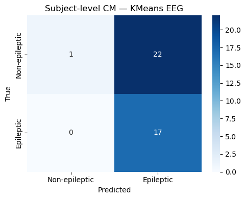

```
── Subject-level: KMeans ECG ──
Subjects: 40 | Bal. Acc: 45.52% | Macro F1: 0.3407
               precision    recall  f1-score   support

Non-epileptic       0.40      0.09      0.14        23
    Epileptic       0.40      0.82      0.54        17

     accuracy                           0.40        40
    macro avg       0.40      0.46      0.34        40
 weighted avg       0.40      0.40      0.31        40
```

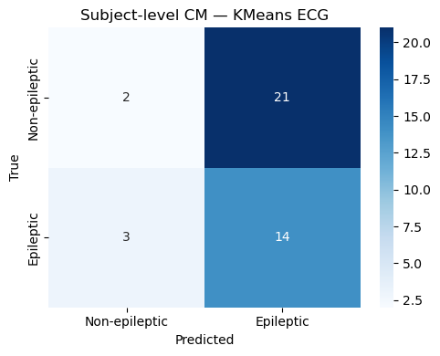

```
── Subject-level: KMeans Fused ──
Subjects: 40 | Bal. Acc: 50.00% | Macro F1: 0.2982
               precision    recall  f1-score   support

Non-epileptic       0.00      0.00      0.00        23
    Epileptic       0.42      1.00      0.60        17

     accuracy                           0.42        40
    macro avg       0.21      0.50      0.30        40
 weighted avg       0.18      0.42      0.25        40
```

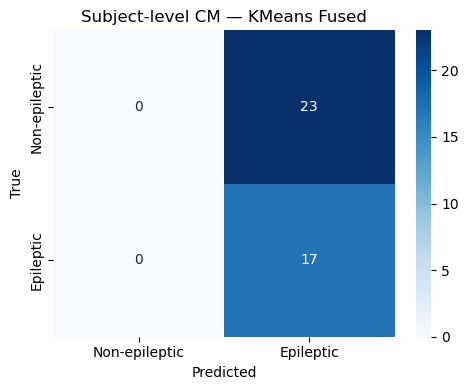

```
── Subject-level: Spectral EEG (subsample) ──
Subjects: 40 | Bal. Acc: 35.93% | Macro F1: 0.3037
               precision    recall  f1-score   support

Non-epileptic       0.30      0.13      0.18        23
    Epileptic       0.33      0.59      0.43        17

     accuracy                           0.33        40
    macro avg       0.32      0.36      0.30        40
 weighted avg       0.31      0.33      0.29        40
```

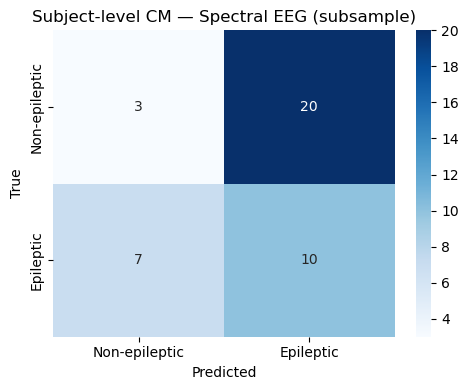

```
── Subject-level: Spectral ECG (subsample) ──
Subjects: 40 | Bal. Acc: 50.00% | Macro F1: 0.2982
               precision    recall  f1-score   support

Non-epileptic       0.00      0.00      0.00        23
    Epileptic       0.42      1.00      0.60        17

     accuracy                           0.42        40
    macro avg       0.21      0.50      0.30        40
 weighted avg       0.18      0.42      0.25        40
```

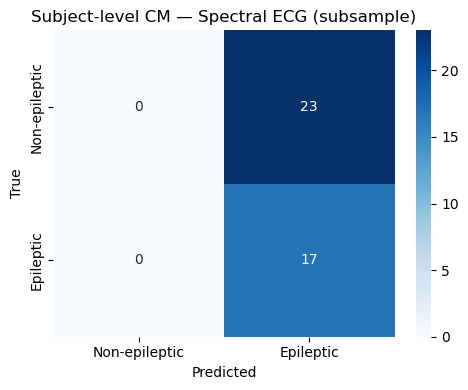

```
── Subject-level: Spectral Fused (subsample) ──
Subjects: 40 | Bal. Acc: 50.00% | Macro F1: 0.2982
               precision    recall  f1-score   support

Non-epileptic       0.00      0.00      0.00        23
    Epileptic       0.42      1.00      0.60        17

     accuracy                           0.42        40
    macro avg       0.21      0.50      0.30        40
 weighted avg       0.18      0.42      0.25        40
```

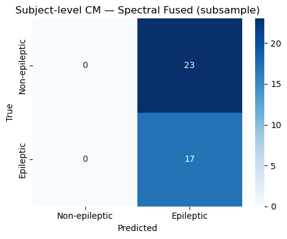

```python
# Subject-level for clustering

from sklearn.metrics import (balanced_accuracy_score, f1_score,
                             confusion_matrix, classification_report)
import seaborn as sns

def subject_level_eval(y_pred, y_true, subjects, name=''):
    subject_preds = {}
    subject_true  = {}

    for subj, pred, true in zip(subjects, y_pred, y_true):
        # Subject appear for the first time
        if subj not in subject_preds:
            subject_preds[subj] = []
            subject_true[subj]  = int(true)
        # Add pediction to the dict
        subject_preds[subj].append(int(pred))

    subj_ids = list(subject_preds.keys())

    # Majority vote
    subj_pred_final = [Counter(subject_preds[s]).most_common(1)[0][0] for s in subj_ids]  # finds the most frequent prediction for each subject.
    subj_true_final = [subject_true[s] for s in subj_ids]  # True labels

    bal_acc = balanced_accuracy_score(subj_true_final, subj_pred_final)
    f1_mac  = f1_score(subj_true_final, subj_pred_final, average='macro')
    f1_w    = f1_score(subj_true_final, subj_pred_final, average='weighted')
    cm      = confusion_matrix(subj_true_final, subj_pred_final)

    print(f'\n── Subject-level: {name} ──')
    print(f'Subjects: {len(subj_ids)} | Bal. Acc: {bal_acc*100:.2f}% | Macro F1: {f1_mac:.4f}')
    print(classification_report(subj_true_final, subj_pred_final,
                                target_names=['Non-epileptic', 'Epileptic']))

    # Confusion matrix
    plt.figure(figsize=(5, 4))
    sns.heatmap(cm, annot=True, fmt='d',
                xticklabels=['Non-epileptic', 'Epileptic'],
                yticklabels=['Non-epileptic', 'Epileptic'],
                cmap='Blues')
    plt.title(f'Subject-level CM — {name}')
    plt.ylabel('True')
    plt.xlabel('Predicted')
    plt.tight_layout()
    plt.show()

    return bal_acc, f1_mac, f1_w, subj_true_final, subj_pred_final

subj_results = {}

for key, res in clustering_results.items():
    bal_acc, f1_mac, f1_w, y_true_s, y_pred_s = subject_level_eval(
        res['km_matched'], all_y, test_subjects, name=f'KMeans {key}'
    )
    subj_results[key] = {
        'bal_acc': bal_acc,
        'f1_mac':  f1_mac,
        'f1_w':    f1_w
    }

# Subject-level for Spectral (subsample only, not all subjects)
for name, res in clustering_results.items():
    subject_level_eval(
        res['sc_matched'],
        all_y[res['idx_sub']],
        test_subjects[res['idx_sub']],
        name=f'Spectral {name} (subsample)'
    )
```

### Downstream classifiers

```python
from sklearn.utils import resample
from sklearn.svm import LinearSVC
from sklearn.ensemble import RandomForestClassifier
from sklearn.linear_model import LogisticRegression
from sklearn.preprocessing import StandardScaler
from sklearn.metrics import classification_report, balanced_accuracy_score, roc_auc_score

# Subsample to 10k balanced for slow classifiers
def get_balanced_subsample(z, y, n_per_class=5000):
    idx_epi  = np.where(y == 1)[0]
    idx_non  = np.where(y == 0)[0]
    idx_epi_s  = resample(idx_epi,  n_samples=n_per_class, random_state=42)
    idx_non_s  = resample(idx_non,  n_samples=n_per_class, random_state=42)
    idx = np.concatenate([idx_epi_s, idx_non_s])
    return z[idx], y[idx]

# Define classifiers
classifiers = {
    'Logistic Regression': LogisticRegression(class_weight='balanced', max_iter=1000),
    'LinearSVM':           LinearSVC(class_weight='balanced', max_iter=2000),
    'Random Forest':       RandomForestClassifier(class_weight='balanced', n_estimators=100, n_jobs=-1)
}
```

```python
# Evaluate on each embedding
embeddings = {
    'EEG':   (all_z_eeg_train,   all_z_eeg),
    'ECG':   (all_z_ecg_train,   all_z_ecg),
    'Fused': (z_fused_train,     z_fused)
}

from sklearn.svm import LinearSVC
from sklearn.calibration import CalibratedClassifierCV

results = {}

for emb_name, (z_train, z_test) in embeddings.items():
    scaler = StandardScaler()
    z_train_sc = scaler.fit_transform(z_train)
    z_test_sc  = scaler.transform(z_test)

    # Subsample train
    z_train_sub, y_train_sub = get_balanced_subsample(z_train_sc, all_y_train)

    for clf_name, clf in classifiers.items():
        print(f'\nFitting {emb_name} + {clf_name}...')

        # Use subsampled data for SVM and RF
        if clf_name in ['LinearSVM', 'Random Forest']:
            clf.fit(z_train_sub, y_train_sub)
        else:
            clf.fit(z_train_sc, all_y_train)

        y_pred = clf.predict(z_test_sc)


        if clf_name == 'LinearSVM':
            cal_clf = CalibratedClassifierCV(clf, cv='prefit')
            cal_clf.fit(z_train_sub, y_train_sub)
            y_prob = cal_clf.predict_proba(z_test_sc)[:, 1]
        else:
            y_prob = clf.predict_proba(z_test_sc)[:, 1]

        bal_acc = balanced_accuracy_score(all_y, y_pred)
        auroc   = roc_auc_score(all_y, y_prob)

        results[f'{emb_name}_{clf_name}'] = {
            'bal_acc': bal_acc,
            'auroc':   auroc,
            'y_pred':  y_pred,
            'y_prob':  y_prob
        }

        print(f'  Balanced Acc: {bal_acc:.4f} | AUROC: {auroc:.4f}')
        print(classification_report(all_y, y_pred,
              target_names=['Non-epileptic', 'Epileptic']))
```

```
Fitting EEG + Logistic Regression...
  Balanced Acc: 0.5101 | AUROC: 0.5064
               precision    recall  f1-score   support

Non-epileptic       0.10      0.53      0.17     20748
    Epileptic       0.91      0.49      0.64    191299

     accuracy                           0.49    212047
    macro avg       0.50      0.51      0.40    212047
 weighted avg       0.83      0.49      0.59    212047


Fitting EEG + LinearSVM...
```

```
  Balanced Acc: 0.5003 | AUROC: 0.5011
               precision    recall  f1-score   support

Non-epileptic       0.10      0.52      0.17     20748
    Epileptic       0.90      0.48      0.62    191299

     accuracy                           0.48    212047
    macro avg       0.50      0.50      0.39    212047
 weighted avg       0.82      0.48      0.58    212047


Fitting EEG + Random Forest...
  Balanced Acc: 0.5424 | AUROC: 0.5601
               precision    recall  f1-score   support

Non-epileptic       0.11      0.52      0.19     20748
    Epileptic       0.92      0.56      0.70    191299

     accuracy                           0.56    212047
    macro avg       0.52      0.54      0.44    212047
 weighted avg       0.84      0.56      0.65    212047


Fitting ECG + Logistic Regression...
  Balanced Acc: 0.6514 | AUROC: 0.6596
               precision    recall  f1-score   support

Non-epileptic       0.19      0.55      0.29     20748
    Epileptic       0.94      0.75      0.83    191299

     accuracy                           0.73    212047
    macro avg       0.57      0.65      0.56    212047
 weighted avg       0.87      0.73      0.78    212047


Fitting ECG + LinearSVM...
```

```
  Balanced Acc: 0.5992 | AUROC: 0.6197
               precision    recall  f1-score   support

Non-epileptic       0.15      0.53      0.23     20748
    Epileptic       0.93      0.67      0.78    191299

     accuracy                           0.66    212047
    macro avg       0.54      0.60      0.51    212047
 weighted avg       0.85      0.66      0.73    212047


Fitting ECG + Random Forest...
  Balanced Acc: 0.5945 | AUROC: 0.6243
               precision    recall  f1-score   support

Non-epileptic       0.16      0.46      0.23     20748
    Epileptic       0.93      0.73      0.82    191299

     accuracy                           0.70    212047
    macro avg       0.54      0.59      0.52    212047
 weighted avg       0.85      0.70      0.76    212047


Fitting Fused + Logistic Regression...
  Balanced Acc: 0.6188 | AUROC: 0.6424
               precision    recall  f1-score   support

Non-epileptic       0.16      0.57      0.25     20748
    Epileptic       0.93      0.67      0.78    191299

     accuracy                           0.66    212047
    macro avg       0.55      0.62      0.51    212047
 weighted avg       0.86      0.66      0.73    212047


Fitting Fused + LinearSVM...
```

```
  Balanced Acc: 0.5646 | AUROC: 0.5902
               precision    recall  f1-score   support

Non-epileptic       0.12      0.55      0.20     20748
    Epileptic       0.92      0.58      0.71    191299

     accuracy                           0.58    212047
    macro avg       0.52      0.56      0.46    212047
 weighted avg       0.84      0.58      0.66    212047


Fitting Fused + Random Forest...
  Balanced Acc: 0.6204 | AUROC: 0.6658
               precision    recall  f1-score   support

Non-epileptic       0.18      0.48      0.26     20748
    Epileptic       0.93      0.76      0.84    191299

     accuracy                           0.74    212047
    macro avg       0.56      0.62      0.55    212047
 weighted avg       0.86      0.74      0.78    212047
```

```
── Subject-level: EEG_Logistic Regression ──
Subjects: 40 | Bal. Acc: 43.73% | Macro F1: 0.4373
               precision    recall  f1-score   support

Non-epileptic       0.52      0.52      0.52        23
    Epileptic       0.35      0.35      0.35        17

     accuracy                           0.45        40
    macro avg       0.44      0.44      0.44        40
 weighted avg       0.45      0.45      0.45        40
```

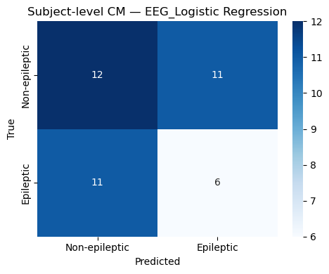

```
── Subject-level: EEG_LinearSVM ──
Subjects: 40 | Bal. Acc: 45.14% | Macro F1: 0.4470
               precision    recall  f1-score   support

Non-epileptic       0.54      0.61      0.57        23
    Epileptic       0.36      0.29      0.32        17

     accuracy                           0.47        40
    macro avg       0.45      0.45      0.45        40
 weighted avg       0.46      0.47      0.47        40
```

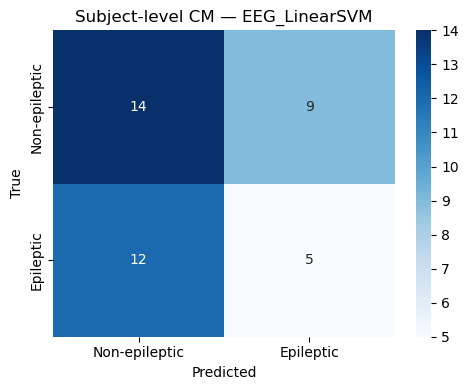

```
── Subject-level: EEG_Random Forest ──
Subjects: 40 | Bal. Acc: 65.86% | Macro F1: 0.6190
               precision    recall  f1-score   support

Non-epileptic       0.83      0.43      0.57        23
    Epileptic       0.54      0.88      0.67        17

     accuracy                           0.62        40
    macro avg       0.68      0.66      0.62        40
 weighted avg       0.71      0.62      0.61        40
```

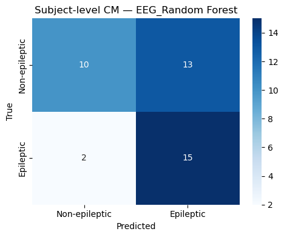

```
── Subject-level: ECG_Logistic Regression ──
Subjects: 40 | Bal. Acc: 62.79% | Macro F1: 0.6229
               precision    recall  f1-score   support

Non-epileptic       0.70      0.61      0.65        23
    Epileptic       0.55      0.65      0.59        17

     accuracy                           0.62        40
    macro avg       0.62      0.63      0.62        40
 weighted avg       0.64      0.62      0.63        40
```

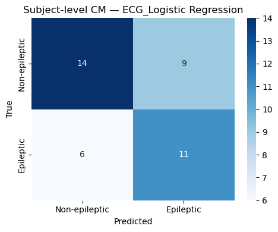

```
── Subject-level: ECG_LinearSVM ──
Subjects: 40 | Bal. Acc: 67.90% | Macro F1: 0.6732
               precision    recall  f1-score   support

Non-epileptic       0.75      0.65      0.70        23
    Epileptic       0.60      0.71      0.65        17

     accuracy                           0.68        40
    macro avg       0.68      0.68      0.67        40
 weighted avg       0.69      0.68      0.68        40
```

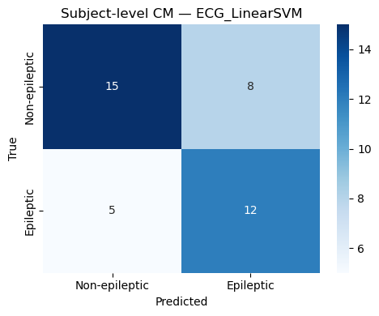

```
── Subject-level: ECG_Random Forest ──
Subjects: 40 | Bal. Acc: 59.21% | Macro F1: 0.5747
               precision    recall  f1-score   support

Non-epileptic       0.69      0.48      0.56        23
    Epileptic       0.50      0.71      0.59        17

     accuracy                           0.57        40
    macro avg       0.59      0.59      0.57        40
 weighted avg       0.61      0.57      0.57        40
```

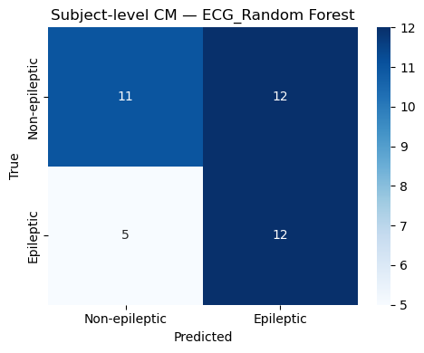

```
── Subject-level: Fused_Logistic Regression ──
Subjects: 40 | Bal. Acc: 59.08% | Macro F1: 0.5908
               precision    recall  f1-score   support

Non-epileptic       0.65      0.65      0.65        23
    Epileptic       0.53      0.53      0.53        17

     accuracy                           0.60        40
    macro avg       0.59      0.59      0.59        40
 weighted avg       0.60      0.60      0.60        40
```

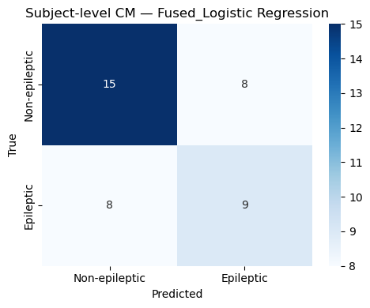

```
── Subject-level: Fused_LinearSVM ──
Subjects: 40 | Bal. Acc: 59.85% | Macro F1: 0.5960
               precision    recall  f1-score   support

Non-epileptic       0.67      0.61      0.64        23
    Epileptic       0.53      0.59      0.56        17

     accuracy                           0.60        40
    macro avg       0.60      0.60      0.60        40
 weighted avg       0.61      0.60      0.60        40
```

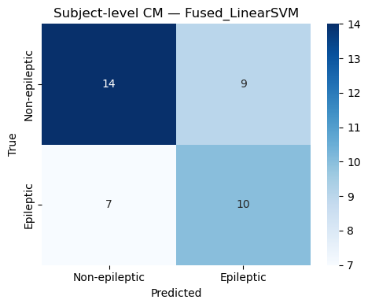

```
── Subject-level: Fused_Random Forest ──
Subjects: 40 | Bal. Acc: 60.61% | Macro F1: 0.5990
               precision    recall  f1-score   support

Non-epileptic       0.68      0.57      0.62        23
    Epileptic       0.52      0.65      0.58        17

     accuracy                           0.60        40
    macro avg       0.60      0.61      0.60        40
 weighted avg       0.62      0.60      0.60        40
```

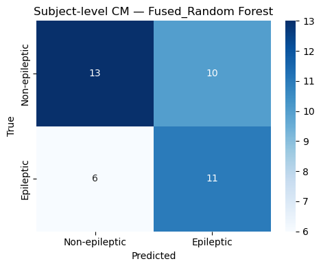

```python
# Subject-level for classifiers

subj_results_clf = {}

for key, res in results.items():
    bal_acc, f1_mac, f1_w, y_true_s, y_pred_s = subject_level_eval(
        res['y_pred'], all_y, test_subjects, name=key
    )
    subj_results_clf[key] = {
        'bal_acc': bal_acc,
        'f1_mac':  f1_mac,
        'f1_w':    f1_w
    }
```

To be more precise I'm then evaluating on a subject level using majority voting

# Cluster visualization

```python
import umap

reducer_fused = umap.UMAP(n_components=2, random_state=42, n_neighbors=30, min_dist=0.1)
z_fused_2d = reducer_fused.fit_transform(z_fused)

cluster_labels = clustering_results['Fused']['km_matched']

df = pd.DataFrame({
    'x':       z_fused_2d[:, 0],
    'y':       z_fused_2d[:, 1],
    'label':   ['Epileptic' if y == 1 else 'Non-epileptic' for y in all_y],
    'cluster': [f'Cluster {c}' for c in cluster_labels],
    'subject': test_subjects
})

# True labels
fig1 = px.scatter(df, x='x', y='y', color='label',
                  hover_data=['subject'],
                  color_discrete_map={'Epileptic': 'tomato', 'Non-epileptic': 'steelblue'},
                  opacity=0.5, title='UMAP — True Labels (Test Set)')
fig1.update_traces(marker=dict(size=3))
fig1.show()

# Cluster assignments
fig2 = px.scatter(df, x='x', y='y', color='cluster',
                  hover_data=['subject', 'label'],
                  opacity=0.5, title='UMAP — KMeans Clusters (Test Set)')
fig2.update_traces(marker=dict(size=3))
fig2.show()
```

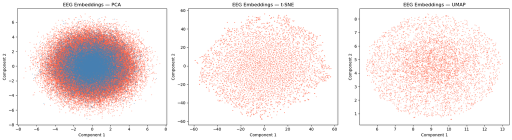

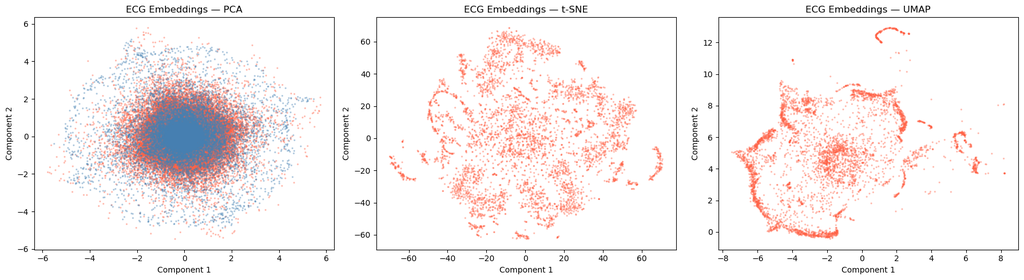

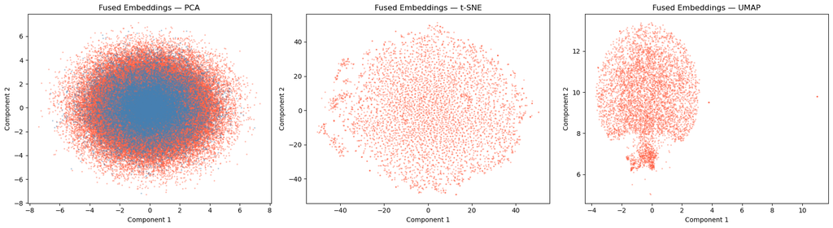

```python
from sklearn.decomposition import PCA
from sklearn.manifold import TSNE
import umap

def visualize_embeddings(z, labels, title):
    fig, axes = plt.subplots(1, 3, figsize=(18, 5))

    # PCA
    pca = PCA(n_components=2)
    z_pca = pca.fit_transform(z)

    # t-SNE
    tsne = TSNE(n_components=2, perplexity=30, random_state=42)
    z_tsne = tsne.fit_transform(z[:5000])  # subsample for speed

    # UMAP
    reducer = umap.UMAP(n_components=2, random_state=42)
    z_umap = reducer.fit_transform(z)

    for ax, z_2d, method in zip(axes,
                                 [z_pca, z_tsne, z_umap[:5000]],
                                 ['PCA', 't-SNE', 'UMAP']):
        colors = ['tomato' if l == 1 else 'steelblue' for l in labels[:len(z_2d)]]
        ax.scatter(z_2d[:, 0], z_2d[:, 1], c=colors, alpha=0.3, s=2)
        ax.set_title(f'{title} — {method}')
        ax.set_xlabel('Component 1')
        ax.set_ylabel('Component 2')

    plt.tight_layout()
    plt.show()

# Plot all three embeddings
visualize_embeddings(all_z_eeg,  all_y, 'EEG Embeddings')
visualize_embeddings(all_z_ecg,  all_y, 'ECG Embeddings')
visualize_embeddings(z_fused,    all_y, 'Fused Embeddings')
```

```python
import pandas as pd

rows = []

# Clustering results
for name, res in clustering_results.items():
    # KMeans window-level
    km_acc, km_matched = clustering_accuracy(all_y, res['km_matched'])
    km_rioc = (km_acc - 0.5) / 0.5 * 100

    # KMeans subject-level
    km_subj = subj_results.get(name, {})

    rows.append({
        'Method':          'KMeans',
        'Embedding':       name,
        'Window Acc':      f'{km_acc*100:.2f}%',
        'Window RIOC':     f'{km_rioc:.2f}%',
        'Window Bal.Acc':  '—',
        'Window AUROC':    '—',
        'Window Macro F1': '—',
        'Subj Bal.Acc':    f"{km_subj.get('bal_acc', 0)*100:.2f}%",
        'Subj Macro F1':   f"{km_subj.get('f1_mac', 0):.4f}"
    })

# Downstream classifier results
for key, res in results.items():
    emb, clf = key.split('_', 1)
    subj = subj_results_clf.get(key, {})

    rows.append({
        'Method':          clf,
        'Embedding':       emb,
        'Window Acc':      '—',
        'Window RIOC':     '—',
        'Window Bal.Acc':  f"{res['bal_acc']*100:.2f}%",
        'Window AUROC':    f"{res['auroc']:.4f}",
        'Window Macro F1': '—',
        'Subj Bal.Acc':    f"{subj.get('bal_acc', 0)*100:.2f}%",
        'Subj Macro F1':   f"{subj.get('f1_mac', 0):.4f}"
    })

df_summary = pd.DataFrame(rows)
print(df_summary.to_string(index=False))


df_summary.to_csv('results_summary.csv', index=False)


print('\nPaper baseline — CNN-DCCAE (Spectral, Fused): Acc=68.704% | RIOC=37.41%')
```

```
             Method Embedding Window Acc Window RIOC Window Bal.Acc Window AUROC Window Macro F1 Subj Bal.Acc Subj Macro F1
             KMeans       EEG     56.59%      13.18%              —            —               —       52.17%        0.3452
             KMeans       ECG     60.03%      20.06%              —            —               —       45.52%        0.3407
             KMeans     Fused     61.57%      23.15%              —            —               —       50.00%        0.2982
Logistic Regression       EEG          —           —         51.01%       0.5064               —       43.73%        0.4373
          LinearSVM       EEG          —           —         50.03%       0.5011               —       45.14%        0.4470
      Random Forest       EEG          —           —         54.24%       0.5601               —       65.86%        0.6190
Logistic Regression       ECG          —           —         65.14%       0.6596               —       62.79%        0.6229
          LinearSVM       ECG          —           —         59.92%       0.6197               —       67.90%        0.6732
      Random Forest       ECG          —           —         59.45%       0.6243               —       59.21%        0.5747
Logistic Regression     Fused          —           —         61.88%       0.6424               —       59.08%        0.5908
          LinearSVM     Fused          —           —         56.46%       0.5902               —       59.85%        0.5960
      Random Forest     Fused          —           —         62.04%       0.6658               —       60.61%        0.5990

Paper baseline — CNN-DCCAE (Spectral, Fused): Acc=68.704% | RIOC=37.41%
```

By this representaions we can see that the classes are very mixed, so the encoder has not learned.

By the spectral clustering, it has found something real, but not related to the separation between epileptic and non-epileptic.

(i'm going to try to plot by subject id to check if that is the bias)

I still did not introduce the sampler for balancing the classes tho

# Spervised fine-tunning

freeze (faster) or unfreeze (better results) encoders

add classifier head

train with labels + class balancing

```python
# Balance classes
labels = [train_paired[i][2] for i in range(len(train_paired))]
class_counts = np.bincount(labels)
sample_weights = [1.0 / class_counts[l] for l in labels]
sampler = WeightedRandomSampler(sample_weights, num_samples=len(sample_weights), replacement=True)
train_loader_balanced = DataLoader(train_paired, batch_size=32, sampler=sampler)
```

```python
class DCCAEClassifier(nn.Module):
    def __init__(self, dccae_model, latent_dim=25):
        super().__init__()
        self.eeg_encoder = dccae_model.eeg_encoder
        self.ecg_encoder = dccae_model.ecg_encoder

        # Freeze encoders
        for param in self.eeg_encoder.parameters():
            param.requires_grad = False
        for param in self.ecg_encoder.parameters():
            param.requires_grad = False

        self.classifier = nn.Sequential(
            nn.Linear(latent_dim * 2, 64),
            nn.LeakyReLU(0.1),
            nn.Dropout(0.3),
            nn.Linear(64, 32),
            nn.LeakyReLU(0.1),
            nn.Dropout(0.3),
            nn.Linear(32, 1)
        )

    def forward(self, eeg, ecg):
        with torch.no_grad():
            z_eeg = self.eeg_encoder(eeg)
            z_ecg = self.ecg_encoder(ecg)
        z_fused = torch.cat([z_eeg, z_ecg], dim=-1)
        return self.classifier(z_fused)


model.load_state_dict(torch.load('best_dccae_lr.pth', weights_only=True))
classifier = DCCAEClassifier(model).to(device)
```

```python
# 9:1 imbalance
pos_weight = torch.tensor([9.0]).to(device)
criterion = nn.BCEWithLogitsLoss(pos_weight=pos_weight)
```

```python
optimizer = torch.optim.Adam(
    filter(lambda p: p.requires_grad, classifier.parameters()),
    lr=1e-3
)

epochs = 20
patience = 8
epochs_no_improve = 0
```

```python
# from sklearn.metrics import balanced_accuracy_score, roc_auc_score, f1_score

# train_losses = []
# val_losses = []
# best_bal_acc = 0.0
# epochs_no_improve = 0


# for epoch in range(epochs):
#     classifier.train()
#     total_train_loss = 0.0

#     for eeg, ecg, y, _ in tqdm(train_loader_balanced, desc=f'Epoch {epoch+1}/{epochs}', leave=False):
#         eeg = eeg.to(device)
#         ecg = ecg.to(device)
#         y = y.float().to(device)

#         optimizer.zero_grad()
#         logits = classifier(eeg, ecg).squeeze(1)

#         loss = criterion(logits, y)

#         loss.backward()

#         optimizer.step()
#         total_train_loss += loss.item()

#     avg_train_loss = total_train_loss / len(train_loader_balanced)
#     train_losses.append(avg_train_loss)


#     # Validation
#     classifier.eval()
#     total_val_loss = 0.0

#     all_logits, all_y_val = [], []
#     with torch.no_grad():
#         for eeg, ecg, y, _ in val_loader:
#             eeg, ecg = eeg.to(device), ecg.to(device)
#             y = y.float().to(device)
#             logits = classifier(eeg, ecg).squeeze(1)
#             loss = criterion(logits, y)
#             total_val_loss += loss.item()
#             all_logits.append(logits.cpu())
#             all_y_val.append(y.cpu())

#     avg_val_loss = total_val_loss / len(val_loader)
#     val_losses.append(avg_val_loss)

#     all_logits = torch.cat(all_logits)
#     all_y_val = torch.cat(all_y_val)
#     probs = torch.sigmoid(all_logits).numpy()
#     threshold = class_counts[0] / (class_counts[0] + class_counts[1])  # ~0.1 for 9:1 imbalance
#     preds = (probs > threshold).astype(int)

#     bal_acc = balanced_accuracy_score(all_y_val.numpy(), preds)
#     auroc = roc_auc_score(all_y_val.numpy(), probs)
#     print(f'Epoch {epoch+1} - Train: {avg_train_loss:.4f} | Val: {avg_val_loss:.4f} | BalAcc: {bal_acc:.4f} | AUROC: {auroc:.4f}')


#     if bal_acc > best_bal_acc:
#         best_bal_acc = bal_acc
#         torch.save(classifier.state_dict(), 'best_dccae_classifier.pth')
#         print(f'New best model saved (bal acc: {best_bal_acc:.4f})')
#         epochs_no_improve = 0

#     else:
#         epochs_no_improve += 1
#         if epochs_no_improve >= patience:
#             print(f'Early stopping at epoch {epoch+1}')
#             break

# plt.figure(figsize=(8, 5))
# plt.plot(train_losses, label='Train Loss')
# plt.plot(val_losses, label='Val Loss')
# plt.xlabel('Epoch')
# plt.ylabel('Loss')
# plt.title('Training Loss Curve')
# plt.legend()
# plt.show()
```

```python
from sklearn.metrics import roc_curve

classifier.load_state_dict(torch.load('best_dccae_classifier.pth', weights_only=True))
classifier.eval()

all_logits, all_y_val = [], []
with torch.no_grad():
    for eeg, ecg, y, _ in val_loader:
        eeg, ecg = eeg.to(device), ecg.to(device)
        logits = classifier(eeg, ecg).squeeze(1)
        all_logits.append(logits.cpu())
        all_y_val.append(y.cpu())

probs = torch.sigmoid(torch.cat(all_logits)).numpy()
y_val = torch.cat(all_y_val).numpy()

# Find threshold that maximises balanced accuracy
fpr, tpr, thresholds = roc_curve(y_val, probs)
balanced_accs = (tpr + (1 - fpr)) / 2
best_idx = np.argmax(balanced_accs)
best_threshold = thresholds[best_idx]
print(f'Best threshold: {best_threshold:.4f}')
print(f'Best balanced accuracy: {balanced_accs[best_idx]:.4f}')
```

```
Best threshold: 0.9114
Best balanced accuracy: 0.6282
```

```python
classifier.load_state_dict(torch.load('best_dccae_classifier.pth', weights_only=True))
classifier.eval()

all_logits, all_y_test = [], []
with torch.no_grad():
    for eeg, ecg, y, _ in test_loader:
        eeg, ecg = eeg.to(device), ecg.to(device)
        logits = classifier(eeg, ecg).squeeze(1)
        all_logits.append(logits.cpu())
        all_y_test.append(y.cpu())

y_prob_supervised = torch.sigmoid(torch.cat(all_logits)).numpy()


y_pred_supervised = (y_prob_supervised > best_threshold).astype(int)
bal_acc_tuned = balanced_accuracy_score(all_y, y_pred_supervised)
print(f'Balanced accuracy with tuned threshold: {bal_acc_tuned:.4f}')
```

```
Balanced accuracy with tuned threshold: 0.5715
```

```python
bal_acc = balanced_accuracy_score(all_y, y_pred_supervised)
auroc   = roc_auc_score(all_y, y_prob_supervised)
print(f'Balanced accuracy: {bal_acc:.4f}')
print(f'AUROC: {auroc:.4f}')
print(classification_report(all_y, y_pred_supervised,
      target_names=['Non-epileptic', 'Epileptic']))
```

```
Balanced accuracy: 0.5715
AUROC: 0.6146
               precision    recall  f1-score   support

Non-epileptic       0.12      0.61      0.21     20748
    Epileptic       0.93      0.54      0.68    191299

     accuracy                           0.54    212047
    macro avg       0.53      0.57      0.44    212047
 weighted avg       0.85      0.54      0.63    212047
```

```
── Subject-level: MLP Classifier (frozen encoders) ──
Subjects: 40 | Bal. Acc: 48.85% | Macro F1: 0.4885
               precision    recall  f1-score   support

Non-epileptic       0.57      0.57      0.57        23
    Epileptic       0.41      0.41      0.41        17

     accuracy                           0.50        40
    macro avg       0.49      0.49      0.49        40
 weighted avg       0.50      0.50      0.50        40
```

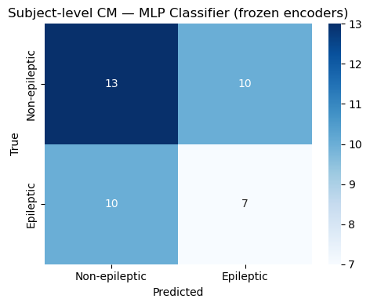

```python
# Subject-level evaluation
bal_acc, f1_mac, f1_w, _, _ = subject_level_eval(
    y_pred_supervised, all_y, test_subjects, name='MLP Classifier (frozen encoders)'
)
```

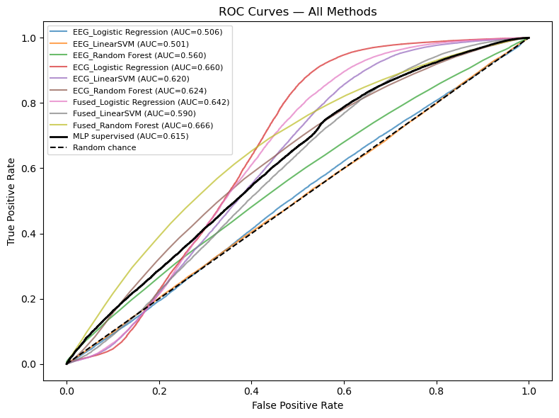

```python
from sklearn.metrics import roc_curve, auc
import matplotlib.pyplot as plt

plt.figure(figsize=(8, 6))

for key, res in results.items():
    fpr, tpr, _ = roc_curve(all_y, res['y_prob'])  # now works
    plt.plot(fpr, tpr, label=f"{key} (AUC={res['auroc']:.3f})", alpha=0.7)

fpr, tpr, _ = roc_curve(all_y, y_prob_supervised)
roc_auc = auc(fpr, tpr)
plt.plot(fpr, tpr, label=f'MLP supervised (AUC={roc_auc:.3f})', linewidth=2, color='black')

plt.plot([0, 1], [0, 1], 'k--', label='Random chance')
plt.xlabel('False Positive Rate')
plt.ylabel('True Positive Rate')
plt.title('ROC Curves — All Methods')
plt.legend(fontsize=8)
plt.tight_layout()
plt.show()
```